# Standart Ölçmə Xətası (SEM)

SEM Anlayışı, Hesablanması və İnterpretasiyası

Klassik Test Nəzəriyyəsi Kursu - Dərs 9

2025-07-17

## 0.1 Dərsin Məqsədləri

✓ Standart Ölçmə Xətası (SEM) anlayışını və riyazi əsaslarını öyrənmək  
✓ SEM formulasını anlamaq və hesablama metodlarını mənimsəmək  
✓ SEM və etibarlılıq arasındakı əlaqəni dərindən öyrənmək  
✓ SEM-in praktiki interpretasiyasını və istifadə sahələrini mənimsəmək

## 0.2 Əvvəlki Dərslərə Baxış

**Dərs 1-8-də öyrəndiklərimiz:** - **Klassik Test Nəzəriyyəsi (CTT)** əsasları: X = T + E - **Etibarlılıq** konsepti və hesablama metodları - **Cronbach’s Alpha** və digər etibarlılıq əmsalları - **True Score və Error Score** arasında əlaqə

**İndi fokus:** Test nəticələrində **xəta miqdarını** dəqiq ölçmək - **Standart Ölçmə Xətası (SEM)**

# 1 Standart Ölçmə Xətası (SEM) Anlayışı

## 1.1 Təyin və Mahiyyət

**Standart Ölçmə Xətası (SEM)** fərdin müşahidə olunan balının həqiqi balından nə qədər fərqlənə biləcəyini göstərən ölçüdür.

### 1.1.1 Əsas Konsept

```r
cat("=== STANDART ÖLÇMƏ XƏTASI (SEM) ƏSAS KONSEPTİ ===\n\n")
```

```
## === STANDART ÖLÇMƏ XƏTASI (SEM) ƏSAS KONSEPTİ ===
```

```r
# SEM simulyasiyası
set.seed(123)
n_people <- 1000
true_scores <- rnorm(n_people, mean = 50, sd = 10)

# Müxtəlif etibarlılıq səviyyələri üçün müşahidə olunan ballar
reliability_levels <- c(0.95, 0.90, 0.80, 0.70, 0.60)
observed_scores_list <- list()

for(i in 1:length(reliability_levels)) {
  rel <- reliability_levels[i]
  error_variance <- var(true_scores) * (1 - rel)
  error_scores <- rnorm(n_people, mean = 0, sd = sqrt(error_variance))
  observed_scores_list[[i]] <- true_scores + error_scores
}

names(observed_scores_list) <- paste0("r_", reliability_levels)

cat("SEM KONSEPTİNİN İZAHI:\n\n")
```

```
## SEM KONSEPTİNİN İZAHI:
```

```r
# SEM anlayışının izahı
sem_concept <- data.frame(
  Konsept = c("True Score (T)", "Error Score (E)", "Observed Score (X)",
              "SEM", "Etibarlılıq"),
  Simvol = c("T", "E", "X", "SEM", "ρₓₓ"),
  Mahiyyət = c("Fərdin həqiqi qabiliyyəti", "Ölçmə xətası", "Müşahidə olunan bal",
               "Xətanın standart sapması", "True score variansının nisbəti"),
  Formula = c("Sabit dəyər", "E ~ N(0, σₑ²)", "X = T + E",
              "SEM = σₓ√(1-ρₓₓ)", "ρₓₓ = σₜ²/σₓ²"),
  İnterpretasiya = c("Dəyişməz", "Təsadüfi", "Ölçdüyümüz",
                     "Xəta miqdarı", "Dəqiqlik ölçüsü")
)

kable(sem_concept, caption = "SEM və Əlaqəli Konseptlər")
```

SEM və Əlaqəli Konseptlər

| Konsept | Simvol | Mahiyyət | Formula | İnterpretasiya |
| --- | --- | --- | --- | --- |
| True Score (T) | T | Fərdin həqiqi qabiliyyəti | Sabit dəyər | Dəyişməz |
| Error Score (E) | E | Ölçmə xətası | E ~ N(0, σₑ²) | Təsadüfi |
| Observed Score (X) | X | Müşahidə olunan bal | X = T + E | Ölçdüyümüz |
| SEM | SEM | Xətanın standart sapması | SEM = σₓ√(1-ρₓₓ) | Xəta miqdarı |
| Etibarlılıq | ρₓₓ | True score variansının nisbəti | ρₓₓ = σₜ²/σₓ² | Dəqiqlik ölçüsü |

```r
# Nümunə hesablama
example_sd <- 10
example_reliability <- 0.85
example_sem <- example_sd * sqrt(1 - example_reliability)

cat("\nNÜMUNƏ HESABLAMA:\n")
```

```
##
## NÜMUNƏ HESABLAMA:
```

```r
cat("Test standart sapması (σₓ):", example_sd, "\n")
```

```
## Test standart sapması (σₓ): 10
```

```r
cat("Etibarlılıq (ρₓₓ):", example_reliability, "\n")
```

```
## Etibarlılıq (ρₓₓ): 0.85
```

```r
cat("SEM = σₓ√(1-ρₓₓ) =", example_sd, "× √(1-", example_reliability, ") =",
    round(example_sem, 2), "\n\n")
```

```
## SEM = σₓ√(1-ρₓₓ) = 10 × √(1- 0.85 ) = 3.87
```

```r
cat("İNTERPRETASİYA:\n")
```

```
## İNTERPRETASİYA:
```

```r
cat("Bu o deməkdir ki, fərdin müşahidə olunan balı həqiqi balından\n")
```

```
## Bu o deməkdir ki, fərdin müşahidə olunan balı həqiqi balından
```

```r
cat("orta hesabla", round(example_sem, 2), "bal qədər fərqlənə bilər.\n\n")
```

```
## orta hesabla 3.87 bal qədər fərqlənə bilər.
```

### 1.1.2 SEM vs Digər Xəta Ölçüləri

```r
# SEM və digər xəta ölçülərinin müqayisəsi

error_measures_comparison <- data.frame(
  Ölçü = c("SEM", "Standard Error", "Confidence Interval", "Prediction Interval", "RMSE"),

  Məqsəd = c("Individual xəta", "Sample xəta", "Parameter aralığı",
             "Gələcək nəticə aralığı", "Model xətası"),

  Formula = c("σₓ√(1-ρₓₓ)", "σ/√n", "x̄ ± z×SE", "ŷ ± z×σ", "√(Σ(y-ŷ)²/n)"),

  İstifadə_Sahəsi = c("Test nəticələri", "Statistik nəticələr", "Parameter qiymətləndirmə",
                      "Gələcək proqnozlar", "Model qiymətləndirmə"),

  Interpretasiya = c("Fərdi balın xətası", "Orta balın xətası", "Parametr dəqiqliyi",
                     "Yeni nəticə dəqiqliyi", "Model performansı")
)

kable(error_measures_comparison, caption = "SEM və Digər Xəta Ölçülərinin Müqayisəsi")
```

SEM və Digər Xəta Ölçülərinin Müqayisəsi

| Ölçü | Məqsəd | Formula | İstifadə_Sahəsi | Interpretasiya |
| --- | --- | --- | --- | --- |
| SEM | Individual xəta | σₓ√(1-ρₓₓ) | Test nəticələri | Fərdi balın xətası |
| Standard Error | Sample xəta | σ/√n | Statistik nəticələr | Orta balın xətası |
| Confidence Interval | Parameter aralığı | x̄ ± z×SE | Parameter qiymətləndirmə | Parametr dəqiqliyi |
| Prediction Interval | Gələcək nəticə aralığı | ŷ ± z×σ | Gələcək proqnozlar | Yeni nəticə dəqiqliyi |
| RMSE | Model xətası | √(Σ(y-ŷ)²/n) | Model qiymətləndirmə | Model performansı |

```r
# SEM-in üstünlükləri
cat("SEM-İN ÜSTÜNLÜKLƏRI:\n")
```

```
## SEM-İN ÜSTÜNLÜKLƏRI:
```

```r
sem_advantages <- c(
  "• Fərdi nəticələrin interpretasiyası üçün idealdır",
  "• Etibarlılıqla birbaşa əlaqəlidir",
  "• Test performansının praktiki qiymətləndirməsini təmin edir",
  "• Güven aralıqları hesablamaq üçün istifadə olunur",
  "• Test inkişafı və təkmilləşdirməsi üçün vacibdir"
)

for(advantage in sem_advantages) {
  cat(advantage, "\n")
}
```

```
## • Fərdi nəticələrin interpretasiyası üçün idealdır
## • Etibarlılıqla birbaşa əlaqəlidir
## • Test performansının praktiki qiymətləndirməsini təmin edir
## • Güven aralıqları hesablamaq üçün istifadə olunur
## • Test inkişafı və təkmilləşdirməsi üçün vacibdir
```

# 2 SEM Formulası və Hesablanması

## 2.1 Əsas Formula: SEM = σₓ√(1-ρₓₓ)

```r
cat("=== SEM FORMULASI VƏ HESABLANMASI ===\n\n")
```

```
## === SEM FORMULASI VƏ HESABLANMASI ===
```

```r
# Formula komponentlərinin izahı
formula_components <- data.frame(
  Simvol = c("SEM", "σₓ", "ρₓₓ", "√(1-ρₓₓ)", "1-ρₓₓ"),

  Adı = c("Standart Ölçmə Xətası", "Test standart sapması", "Etibarlılıq əmsalı",
          "Xəta faktoru", "Xəta variansı nisbəti"),

  Mahiyyət = c("Xətanın standart sapması", "Müşahidə olunan balların dağılımı",
               "True score variansının nisbəti", "Xəta miqdarının kökü",
               "Error variance nisbəti"),

  Tipik_Dəyər = c("1-5 bal", "5-20 bal", "0.60-0.95", "0.22-0.63", "0.05-0.40"),

  İnterpretasiya = c("Aşağı = yaxşı", "Test çətinliyindən asılı", "Yüksək = yaxşı",
                     "Aşağı = yaxşı", "Aşağı = yaxşı")
)

kable(formula_components, caption = "SEM Formulasının Komponentləri")
```

SEM Formulasının Komponentləri

| Simvol | Adı | Mahiyyət | Tipik_Dəyər | İnterpretasiya |
| --- | --- | --- | --- | --- |
| SEM | Standart Ölçmə Xətası | Xətanın standart sapması | 1-5 bal | Aşağı = yaxşı |
| σₓ | Test standart sapması | Müşahidə olunan balların dağılımı | 5-20 bal | Test çətinliyindən asılı |
| ρₓₓ | Etibarlılıq əmsalı | True score variansının nisbəti | 0.60-0.95 | Yüksək = yaxşı |
| √(1-ρₓₓ) | Xəta faktoru | Xəta miqdarının kökü | 0.22-0.63 | Aşağı = yaxşı |
| 1-ρₓₓ | Xəta variansı nisbəti | Error variance nisbəti | 0.05-0.40 | Aşağı = yaxşı |

```r
# SEM hesablama addımları
cat("\nSEM HESABLAMA ADDIMMLARI:\n\n")
```

```
##
## SEM HESABLAMA ADDIMMLARI:
```

```r
# Nümunə məlumatlar
set.seed(456)
test_scores <- rnorm(200, mean = 75, sd = 12)
test_reliability <- 0.88

# Manual SEM hesablaması
step1_sd <- sd(test_scores)
step2_reliability <- test_reliability
step3_error_ratio <- 1 - step2_reliability
step4_error_factor <- sqrt(step3_error_ratio)
step5_sem <- step1_sd * step4_error_factor

# Hesablama addımları cədvəli
calculation_steps <- data.frame(
  Addım = 1:5,
  Əməliyyat = c("σₓ hesablama", "ρₓₓ müəyyən etmə", "1-ρₓₓ hesablama",
                "√(1-ρₓₓ) hesablama", "SEM = σₓ × √(1-ρₓₓ)"),
  Dəyər = c(round(step1_sd, 2), step2_reliability, round(step3_error_ratio, 3),
            round(step4_error_factor, 3), round(step5_sem, 2)),
  İzah = c("Test ballarının standart sapması", "Cronbach's Alpha və ya test-retest",
           "Xəta variansı nisbəti", "Xəta faktoru", "Final SEM dəyəri")
)

kable(calculation_steps, caption = "SEM Manual Hesablama Addımları")
```

SEM Manual Hesablama Addımları

| Addım | Əməliyyat | Dəyər | İzah |
| --- | --- | --- | --- |
| 1 | σₓ hesablama | 11.900 | Test ballarının standart sapması |
| 2 | ρₓₓ müəyyən etmə | 0.880 | Cronbach’s Alpha və ya test-retest |
| 3 | 1-ρₓₓ hesablama | 0.120 | Xəta variansı nisbəti |
| 4 | √(1-ρₓₓ) hesablama | 0.346 | Xəta faktoru |
| 5 | SEM = σₓ × √(1-ρₓₓ) | 4.120 | Final SEM dəyəri |

```r
cat("NÜMUNƏ HESABLAMA NƏTİCƏSİ:\n")
```

```
## NÜMUNƏ HESABLAMA NƏTİCƏSİ:
```

```r
cat("Test standart sapması:", round(step1_sd, 2), "\n")
```

```
## Test standart sapması: 11.9
```

```r
cat("Etibarlılıq əmsalı:", step2_reliability, "\n")
```

```
## Etibarlılıq əmsalı: 0.88
```

```r
cat("SEM:", round(step5_sem, 2), "\n\n")
```

```
## SEM: 4.12
```

```r
cat("İNTERPRETASİYA:\n")
```

```
## İNTERPRETASİYA:
```

```r
cat("Bu test üçün fərdin balı onun həqiqi balından\n")
```

```
## Bu test üçün fərdin balı onun həqiqi balından
```

```r
cat("orta hesabla ±", round(step5_sem, 2), "bal fərqlənə bilər.\n\n")
```

```
## orta hesabla ± 4.12 bal fərqlənə bilər.
```

## 2.2 Müxtəlif Etibarlılıq Səviyyələri üçün SEM

```r
# SEM və etibarlılıq arasında əlaqə

cat("=== SEM VƏ ETİBARLILIQ ƏLAQƏSI ===\n\n")
```

```
## === SEM VƏ ETİBARLILIQ ƏLAQƏSI ===
```

```r
# Müxtəlif etibarlılıq və SD kombinasiyaları üçün SEM hesablama
reliabilities <- seq(0.5, 0.95, 0.05)
standard_deviations <- c(5, 10, 15, 20)

sem_matrix <- matrix(0, nrow = length(standard_deviations), ncol = length(reliabilities))
rownames(sem_matrix) <- paste("SD =", standard_deviations)
colnames(sem_matrix) <- paste("r =", reliabilities)

for(i in 1:length(standard_deviations)) {
  for(j in 1:length(reliabilities)) {
    sd_val <- standard_deviations[i]
    rel_val <- reliabilities[j]
    sem_val <- sd_val * sqrt(1 - rel_val)
    sem_matrix[i, j] <- round(sem_val, 2)
  }
}

cat("SEM CƏDVƏLİ (müxtəlif SD və etibarlılıq üçün):\n")
```

```
## SEM CƏDVƏLİ (müxtəlif SD və etibarlılıq üçün):
```

```r
print(sem_matrix)
```

```
##         r = 0.5 r = 0.55 r = 0.6 r = 0.65 r = 0.7 r = 0.75 r = 0.8 r = 0.85
## SD = 5     3.54     3.35    3.16     2.96    2.74      2.5    2.24     1.94
## SD = 10    7.07     6.71    6.32     5.92    5.48      5.0    4.47     3.87
## SD = 15   10.61    10.06    9.49     8.87    8.22      7.5    6.71     5.81
## SD = 20   14.14    13.42   12.65    11.83   10.95     10.0    8.94     7.75
##         r = 0.9 r = 0.95
## SD = 5     1.58     1.12
## SD = 10    3.16     2.24
## SD = 15    4.74     3.35
## SD = 20    6.32     4.47
```

```r
# Kritik etibarlılıq nöqtələri
cat("\n\nKRİTİK ETİBARLILIQ NÖQTƏLƏRİ (SD = 10 üçün):\n")
```

```
##
##
## KRİTİK ETİBARLILIQ NÖQTƏLƏRİ (SD = 10 üçün):
```

```r
critical_points <- data.frame(
  Etibarlılıq = c(0.60, 0.70, 0.80, 0.85, 0.90, 0.95),
  SEM = round(10 * sqrt(1 - c(0.60, 0.70, 0.80, 0.85, 0.90, 0.95)), 2),
  SEM_Faizi = round(100 * sqrt(1 - c(0.60, 0.70, 0.80, 0.85, 0.90, 0.95)), 1),
  Qiymət = c("Zəif", "Qəbul edilə bilər", "Yaxşı", "Çox yaxşı", "Əla", "Mükəmməl"),
  Praktiki_İstifadə = c("İstifadə etmə", "Ehtiyatla", "Ümumi testlər", "Standart testlər",
                        "Yüksək risk", "Klinik qərarlar")
)

kable(critical_points, caption = "Kritik Etibarlılıq Səviyyələri və SEM")
```

Kritik Etibarlılıq Səviyyələri və SEM

| Etibarlılıq | SEM | SEM_Faizi | Qiymət | Praktiki_İstifadə |
| --- | --- | --- | --- | --- |
| 0.60 | 6.32 | 63.2 | Zəif | İstifadə etmə |
| 0.70 | 5.48 | 54.8 | Qəbul edilə bilər | Ehtiyatla |
| 0.80 | 4.47 | 44.7 | Yaxşı | Ümumi testlər |
| 0.85 | 3.87 | 38.7 | Çox yaxşı | Standart testlər |
| 0.90 | 3.16 | 31.6 | Əla | Yüksək risk |
| 0.95 | 2.24 | 22.4 | Mükəmməl | Klinik qərarlar |

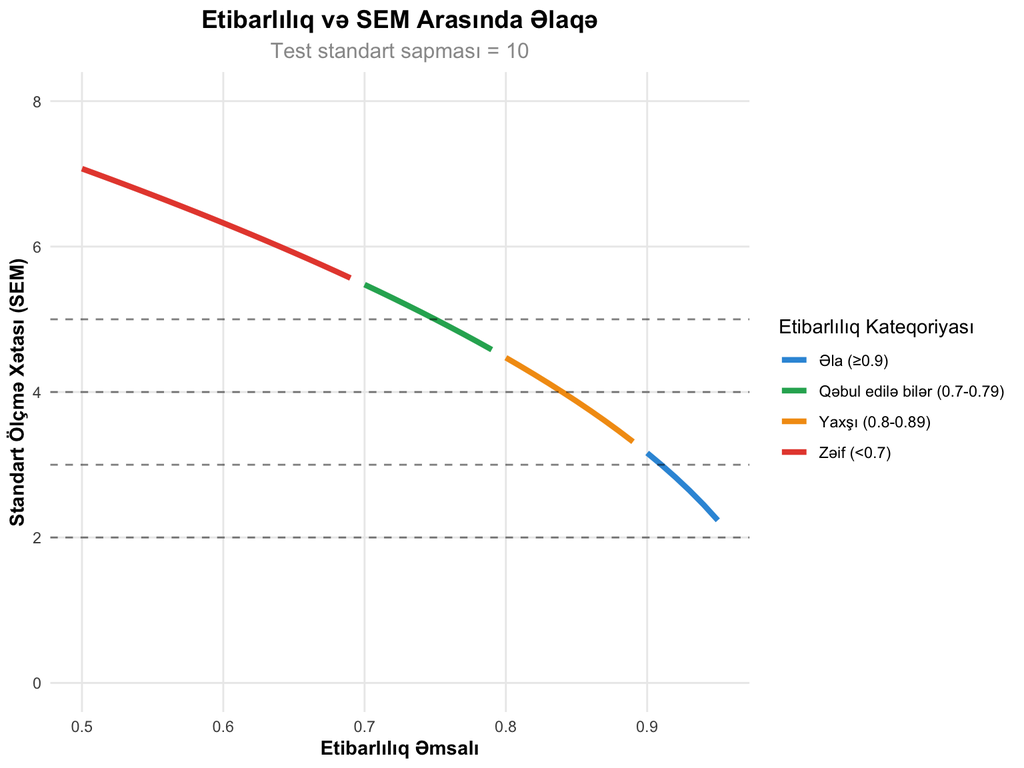

```r
# SEM və etibarlılıq vizuallaşdırma
reliability_range <- seq(0.5, 0.95, 0.01)
sem_values <- 10 * sqrt(1 - reliability_range)

relationship_data <- data.frame(
  Reliability = reliability_range,
  SEM = sem_values,
  Category = ifelse(reliability_range >= 0.9, "Əla (≥0.9)",
                   ifelse(reliability_range >= 0.8, "Yaxşı (0.8-0.89)",
                         ifelse(reliability_range >= 0.7, "Qəbul edilə bilər (0.7-0.79)",
                               "Zəif (<0.7)")))
)

ggplot(relationship_data, aes(x = Reliability, y = SEM, color = Category)) +
  geom_line(size = 1.5) +
  geom_hline(yintercept = c(2, 3, 4, 5), linetype = "dashed", alpha = 0.5) +
  scale_color_manual(values = c("Zəif (<0.7)" = colors_basic[2],
                               "Qəbul edilə bilər (0.7-0.79)" = colors_basic[4],
                               "Yaxşı (0.8-0.89)" = colors_basic[3],
                               "Əla (≥0.9)" = colors_basic[1])) +
  labs(title = "Etibarlılıq və SEM Arasında Əlaqə",
       subtitle = "Test standart sapması = 10",
       x = "Etibarlılıq Əmsalı", y = "Standart Ölçmə Xətası (SEM)",
       color = "Etibarlılıq Kateqoriyası") +
  theme_clean() +
  xlim(0.5, 0.95) +
  ylim(0, 8)
```

## 2.3 R ilə SEM Hesablamaları

```r
cat("=== R İLƏ SEM HESABLAMALARI ===\n\n")
```

```
## === R İLƏ SEM HESABLAMALARI ===
```

```r
# SEM hesablama funksiyası
calculate_sem <- function(scores = NULL, sd_val = NULL, reliability) {
  if(!is.null(scores)) {
    sd_val <- sd(scores, na.rm = TRUE)
  }

  if(is.null(sd_val)) {
    stop("scores və ya sd_val parametrlərindən biri təmin edilməlidir")
  }

  sem <- sd_val * sqrt(1 - reliability)

  return(list(
    sem = sem,
    sd = sd_val,
    reliability = reliability,
    error_ratio = 1 - reliability
  ))
}

# Comprehensive SEM analizi funksiyası
sem_analysis <- function(scores, reliability_estimate) {
  # Əsas statistikalar
  n <- length(scores)
  mean_score <- mean(scores, na.rm = TRUE)
  sd_score <- sd(scores, na.rm = TRUE)

  # SEM hesablama
  sem_result <- calculate_sem(scores = scores, reliability = reliability_estimate)
  sem_value <- sem_result$sem

  # Güven aralıqları (68%, 95%, 99%)
  ci_68 <- c(mean_score - sem_value, mean_score + sem_value)
  ci_95 <- c(mean_score - 1.96 * sem_value, mean_score + 1.96 * sem_value)
  ci_99 <- c(mean_score - 2.58 * sem_value, mean_score + 2.58 * sem_value)

  # SEM-in SD-yə nisbəti
  sem_sd_ratio <- sem_value / sd_score

  # Nəticələr
  results <- list(
    basic_stats = data.frame(
      Statistik = c("N", "Orta", "SD", "SEM", "SEM/SD nisbəti"),
      Dəyər = c(n, round(mean_score, 2), round(sd_score, 2),
                round(sem_value, 2), round(sem_sd_ratio, 3))
    ),
    confidence_intervals = data.frame(
      Səviyyə = c("68%", "95%", "99%"),
      Alt_hədd = round(c(ci_68[1], ci_95[1], ci_99[1]), 2),
      Üst_hədd = round(c(ci_68[2], ci_95[2], ci_99[2]), 2),
      Eni = round(c(diff(ci_68), diff(ci_95), diff(ci_99)), 2)
    ),
    sem_value = sem_value,
    reliability = reliability_estimate
  )

  return(results)
}

# Nümunə məlumatlar yaratma
set.seed(789)
sample_test_scores <- rnorm(150, mean = 80, sd = 15)
sample_reliability <- 0.82

# SEM analizi
analysis_result <- sem_analysis(sample_test_scores, sample_reliability)

cat("NÜMUNƏ SEM ANALİZİ:\n\n")
```

```
## NÜMUNƏ SEM ANALİZİ:
```

```r
cat("ƏSAS STATİSTİKALAR:\n")
```

```
## ƏSAS STATİSTİKALAR:
```

```r
print(kable(analysis_result$basic_stats, caption = "Test Nəticələri Əsas Statistikaları"))
```

```
##
##
## Table: Test Nəticələri Əsas Statistikaları
##
## |Statistik      |   Dəyər|
## |:--------------|-------:|
## |N              | 150.000|
## |Orta           |  79.470|
## |SD             |  14.890|
## |SEM            |   6.320|
## |SEM/SD nisbəti |   0.424|
```

```r
cat("\nGÜVEN ARALIQLARI:\n")
```

```
##
## GÜVEN ARALIQLARI:
```

```r
print(kable(analysis_result$confidence_intervals, caption = "Müxtəlif Güven Səviyyələri üçün Aralıqlar"))
```

```
##
##
## Table: Müxtəlif Güven Səviyyələri üçün Aralıqlar
##
## |Səviyyə | Alt_hədd| Üst_hədd|   Eni|
## |:-------|--------:|--------:|-----:|
## |68%     |    73.15|    85.79| 12.64|
## |95%     |    67.08|    91.85| 24.77|
## |99%     |    63.17|    95.77| 32.60|
```

```r
cat("\nİNTERPRETASİYA:\n")
```

```
##
## İNTERPRETASİYA:
```

```r
cat("• SEM =", round(analysis_result$sem_value, 2), "deməkdir ki, fərdin balı həqiqi balından\n")
```

```
## • SEM = 6.32 deməkdir ki, fərdin balı həqiqi balından
```

```r
cat("  orta hesabla", round(analysis_result$sem_value, 2), "bal fərqlənə bilər\n")
```

```
##   orta hesabla 6.32 bal fərqlənə bilər
```

```r
cat("• 68% ehtimalla fərdin həqiqi balı müşahidə olunan balının ±",
    round(analysis_result$sem_value, 2), "daxilindədir\n")
```

```
## • 68% ehtimalla fərdin həqiqi balı müşahidə olunan balının ± 6.32 daxilindədir
```

```r
cat("• 95% ehtimalla fərdin həqiqi balı müşahidə olunan balının ±",
    round(1.96 * analysis_result$sem_value, 2), "daxilindədir\n\n")
```

```
## • 95% ehtimalla fərdin həqiqi balı müşahidə olunan balının ± 12.38 daxilindədir
```

# 3 SEM-in İnterpretasiyası

## 3.1 Fərdi Bal İnterpretasiyası

```r
cat("=== SEM İLƏ FƏRDİ BAL İNTERPRETASİYASI ===\n\n")
```

```
## === SEM İLƏ FƏRDİ BAL İNTERPRETASİYASI ===
```

```r
# Fərdi bal nümunəsi
individual_score <- 85
test_mean <- 75
test_sd <- 12
test_reliability <- 0.85
test_sem <- test_sd * sqrt(1 - test_reliability)

cat("FƏRDİ BAL NÜMUNƏ ANALİZİ:\n")
```

```
## FƏRDİ BAL NÜMUNƏ ANALİZİ:
```

```r
cat("Müşahidə olunan bal:", individual_score, "\n")
```

```
## Müşahidə olunan bal: 85
```

```r
cat("Test ortası:", test_mean, "\n")
```

```
## Test ortası: 75
```

```r
cat("Test SD:", test_sd, "\n")
```

```
## Test SD: 12
```

```r
cat("Test etibarlılığı:", test_reliability, "\n")
```

```
## Test etibarlılığı: 0.85
```

```r
cat("SEM:", round(test_sem, 2), "\n\n")
```

```
## SEM: 4.65
```

```r
# Güven aralıqları fərdi bal üçün
individual_ci_68 <- c(individual_score - test_sem, individual_score + test_sem)
individual_ci_95 <- c(individual_score - 1.96 * test_sem, individual_score + 1.96 * test_sem)
individual_ci_99 <- c(individual_score - 2.58 * test_sem, individual_score + 2.58 * test_sem)

individual_intervals <- data.frame(
  Güven_Səviyyəsi = c("68%", "95%", "99%"),
  Alt_hədd = round(c(individual_ci_68[1], individual_ci_95[1], individual_ci_99[1]), 1),
  Üst_hədd = round(c(individual_ci_68[2], individual_ci_95[2], individual_ci_99[2]), 1),
  İnterpretasiya = c("Adi dəqiqlik", "Standart dəqiqlik", "Yüksək dəqiqlik"),
  Praktiki_İstifadə = c("Təxmini qiymət", "Klinik qərar", "Kritik qərar")
)

kable(individual_intervals, caption = "Fərdi Bal üçün Güven Aralıqları")
```

Fərdi Bal üçün Güven Aralıqları

| Güven_Səviyyəsi | Alt_hədd | Üst_hədd | İnterpretasiya | Praktiki_İstifadə |
| --- | --- | --- | --- | --- |
| 68% | 80.4 | 89.6 | Adi dəqiqlik | Təxmini qiymət |
| 95% | 75.9 | 94.1 | Standart dəqiqlik | Klinik qərar |
| 99% | 73.0 | 97.0 | Yüksək dəqiqlik | Kritik qərar |

```r
# Z-score və persentil hesablama
z_score <- (individual_score - test_mean) / test_sd
percentile <- pnorm(z_score) * 100

cat("FƏRDİ BAL KONTEKST ANALİZİ:\n")
```

```
## FƏRDİ BAL KONTEKST ANALİZİ:
```

```r
cat("Z-score:", round(z_score, 2), "\n")
```

```
## Z-score: 0.83
```

```r
cat("Persentil:", round(percentile, 1), "\n")
```

```
## Persentil: 79.8
```

```r
cat("Bu fərdin balı ortadan", round(z_score, 2), "standart sapma yuxarıdır\n")
```

```
## Bu fərdin balı ortadan 0.83 standart sapma yuxarıdır
```

```r
cat("və iştirakçıların", round(percentile, 1), "%-dən yüksəkdir.\n\n")
```

```
## və iştirakçıların 79.8 %-dən yüksəkdir.
```

```r
# SEM interpretation guidelines
interpretation_guidelines <- data.frame(
  SEM_Dəyəri = c("< 2", "2-3", "3-5", "5-8", "> 8"),
  Qiymət = c("Əla", "Yaxşı", "Orta", "Zəif", "Çox zəif"),
  İnterpretasiya = c("Çox dəqiq ölçmə", "Dəqiq ölçmə", "Qəbul edilə bilər",
                     "Ehtiyatlı interpretasiya", "Praktiki deyil"),
  Tövsiyə = c("Fərdi qərarlar", "Klinik istifadə", "Qrup müqayisə",
              "Yalnız screening", "Yenidən dizayn"),
  Nümunə_Kontekst = c("IQ testləri", "Achievement testləri", "Şəxsiyyət",
                      "Pilot testlər", "İlkin versiyalar")
)

kable(interpretation_guidelines, caption = "SEM İnterpretasiya Təlimatları")
```

SEM İnterpretasiya Təlimatları

| SEM_Dəyəri | Qiymət | İnterpretasiya | Tövsiyə | Nümunə_Kontekst |
| --- | --- | --- | --- | --- |
| < 2 | Əla | Çox dəqiq ölçmə | Fərdi qərarlar | IQ testləri |
| 2-3 | Yaxşı | Dəqiq ölçmə | Klinik istifadə | Achievement testləri |
| 3-5 | Orta | Qəbul edilə bilər | Qrup müqayisə | Şəxsiyyət |
| 5-8 | Zəif | Ehtiyatlı interpretasiya | Yalnız screening | Pilot testlər |
| > 8 | Çox zəif | Praktiki deyil | Yenidən dizayn | İlkin versiyalar |

## 3.2 SEM və Qərar Vermə

```r
cat("=== SEM VƏ QƏRAR VERMƏ ===\n\n")
```

```
## === SEM VƏ QƏRAR VERMƏ ===
```

```r
# Qərar vermə ssenariləri
decision_scenario <- function(score1, score2, sem, confidence_level = 0.95) {
  # İki bal arasındakı fərq
  score_diff <- abs(score1 - score2)

  # SEM əsaslı minimum fərq
  if(confidence_level == 0.68) {
    critical_diff <- sqrt(2) * sem
  } else if(confidence_level == 0.95) {
    critical_diff <- 1.96 * sqrt(2) * sem
  } else if(confidence_level == 0.99) {
    critical_diff <- 2.58 * sqrt(2) * sem
  }

  # Qərar
  significant_diff <- score_diff >= critical_diff

  return(list(
    score_difference = score_diff,
    critical_difference = critical_diff,
    significant = significant_diff,
    confidence = confidence_level
  ))
}

# Nümunə qərar vermə ssenariləri
cat("QƏRAR VERMƏ SSENARİLƏRİ:\n\n")
```

```
## QƏRAR VERMƏ SSENARİLƏRİ:
```

```r
scenarios <- data.frame(
  Ssenari = c("Student A vs B", "Pre vs Post test", "Test 1 vs Test 2",
              "Müəllim 1 vs 2", "Klinik müqayisə"),
  Bal_1 = c(78, 65, 82, 91, 45),
  Bal_2 = c(84, 72, 79, 88, 52),
  SEM = c(3.5, 4.2, 2.8, 3.0, 4.8),
  Fərq = c(6, 7, 3, 3, 7)
)

# Hər ssenari üçün qərar analizi
scenarios$Critical_Diff_95 <- round(1.96 * sqrt(2) * scenarios$SEM, 1)
scenarios$Significant <- scenarios$Fərq >= scenarios$Critical_Diff_95
scenarios$Qərar <- ifelse(scenarios$Significant, "Əhəmiyyətli fərq", "Əhəmiyyətsiz fərq")

kable(scenarios[, c("Ssenari", "Bal_1", "Bal_2", "Fərq", "Critical_Diff_95", "Qərar")],
      caption = "SEM Əsaslı Qərar Vermə Nümunələri")
```

SEM Əsaslı Qərar Vermə Nümunələri

| Ssenari | Bal_1 | Bal_2 | Fərq | Critical_Diff_95 | Qərar |
| --- | --- | --- | --- | --- | --- |
| Student A vs B | 78 | 84 | 6 | 9.7 | Əhəmiyyətsiz fərq |
| Pre vs Post test | 65 | 72 | 7 | 11.6 | Əhəmiyyətsiz fərq |
| Test 1 vs Test 2 | 82 | 79 | 3 | 7.8 | Əhəmiyyətsiz fərq |
| Müəllim 1 vs 2 | 91 | 88 | 3 | 8.3 | Əhəmiyyətsiz fərq |
| Klinik müqayisə | 45 | 52 | 7 | 13.3 | Əhəmiyyətsiz fərq |

```r
cat("QƏRAR VERMƏ PRİNSİPLƏRİ:\n")
```

```
## QƏRAR VERMƏ PRİNSİPLƏRİ:
```

```r
decision_principles <- c(
  "• İki balın fərqi critical difference-dən böyükdürsə, fərq əhəmiyyətlidir",
  "• Critical difference = 1.96 × √2 × SEM (95% güven üçün)",
  "• Kiçik SEM = daha dəqiq qərarlar",
  "• Böyük SEM = daha ehtiyatlı interpretasiya",
  "• Klinik qərarlarda yüksək güven səviyyəsi istifadə edin (99%)"
)

for(principle in decision_principles) {
  cat(principle, "\n")
}
```

```
## • İki balın fərqi critical difference-dən böyükdürsə, fərq əhəmiyyətlidir
## • Critical difference = 1.96 × √2 × SEM (95% güven üçün)
## • Kiçik SEM = daha dəqiq qərarlar
## • Böyük SEM = daha ehtiyatlı interpretasiya
## • Klinik qərarlarda yüksək güven səviyyəsi istifadə edin (99%)
```

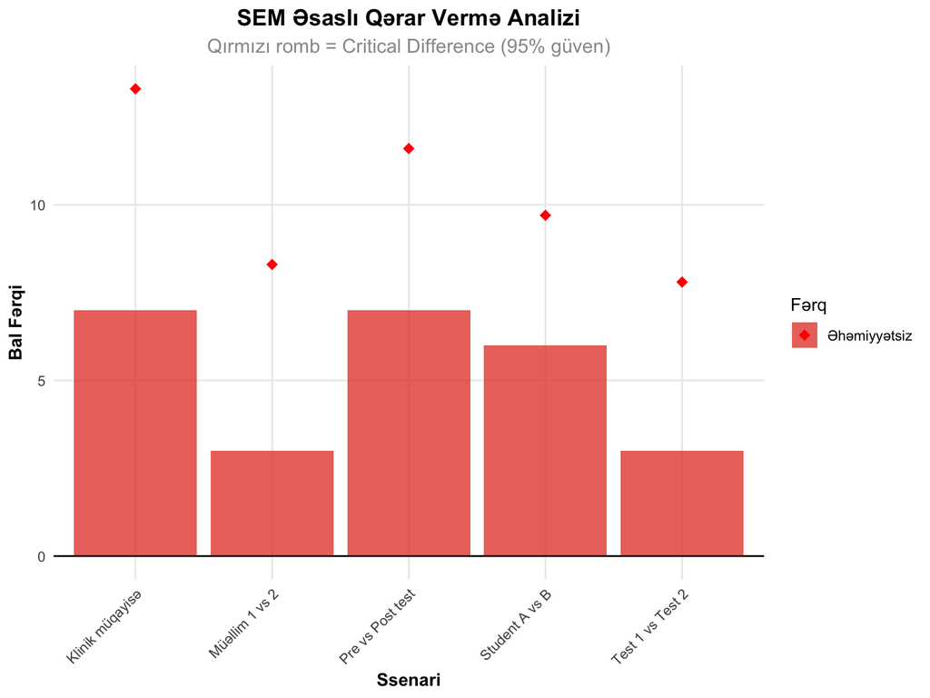

```r
# Qərar vermə vizuallaşdırması
decision_data <- data.frame(
  Scenario = scenarios$Ssenari,
  Difference = scenarios$Fərq,
  Critical_Diff = scenarios$Critical_Diff_95,
  Significant = scenarios$Significant
)

ggplot(decision_data, aes(x = Scenario, y = Difference, fill = Significant)) +
  geom_col(alpha = 0.8) +
  geom_point(aes(y = Critical_Diff), color = "red", size = 3, shape = 18) +
  geom_hline(yintercept = 0, linetype = "solid", color = "black") +
  scale_fill_manual(values = c("FALSE" = colors_basic[2], "TRUE" = colors_basic[1]),
                    labels = c("Əhəmiyyətsiz", "Əhəmiyyətli")) +
  labs(title = "SEM Əsaslı Qərar Vermə Analizi",
       subtitle = "Qırmızı romb = Critical Difference (95% güven)",
       x = "Ssenari", y = "Bal Fərqi",
       fill = "Fərq") +
  theme_clean() +
  theme(axis.text.x = element_text(angle = 45, hjust = 1))
```

## 3.3 SEM və Test Performansı

```r
cat("=== SEM VƏ TEST PERFORMANSI ===\n\n")
```

```
## === SEM VƏ TEST PERFORMANSI ===
```

```r
# Müxtəlif test növləri üçün SEM analizi
test_types <- data.frame(
  Test_Növü = c("IQ Testləri", "Achievement", "Aptitude", "Personality",
                "Klinik Skalalar", "Survey", "Pilot Test"),
  Tipik_SD = c(15, 20, 12, 10, 8, 5, 18),
  Minimum_Reliability = c(0.90, 0.85, 0.80, 0.70, 0.85, 0.60, 0.50),
  Tövsiyə_Reliability = c(0.95, 0.90, 0.85, 0.80, 0.90, 0.75, 0.70)
)

# SEM hesablama hər növ üçün
test_types$SEM_Minimum <- round(test_types$Tipik_SD * sqrt(1 - test_types$Minimum_Reliability), 1)
test_types$SEM_Tövsiyə <- round(test_types$Tipik_SD * sqrt(1 - test_types$Tövsiyə_Reliability), 1)

# SEM performans göstəriciləri
test_types$SEM_Faizi_Min <- round(100 * test_types$SEM_Minimum / test_types$Tipik_SD, 1)
test_types$SEM_Faizi_Töv <- round(100 * test_types$SEM_Tövsiyə / test_types$Tipik_SD, 1)

kable(test_types[, c("Test_Növü", "Tipik_SD", "SEM_Minimum", "SEM_Tövsiyə", "SEM_Faizi_Min", "SEM_Faizi_Töv")],
      caption = "Müxtəlif Test Növləri üçün SEM Analizi")
```

Müxtəlif Test Növləri üçün SEM Analizi

| Test_Növü | Tipik_SD | SEM_Minimum | SEM_Tövsiyə | SEM_Faizi_Min | SEM_Faizi_Töv |
| --- | --- | --- | --- | --- | --- |
| IQ Testləri | 15 | 4.7 | 3.4 | 31.3 | 22.7 |
| Achievement | 20 | 7.7 | 6.3 | 38.5 | 31.5 |
| Aptitude | 12 | 5.4 | 4.6 | 45.0 | 38.3 |
| Personality | 10 | 5.5 | 4.5 | 55.0 | 45.0 |
| Klinik Skalalar | 8 | 3.1 | 2.5 | 38.8 | 31.2 |
| Survey | 5 | 3.2 | 2.5 | 64.0 | 50.0 |
| Pilot Test | 18 | 12.7 | 9.9 | 70.6 | 55.0 |

```r
cat("TEST PERFORMANSI VƏ SEM ƏLAQƏSI:\n")
```

```
## TEST PERFORMANSI VƏ SEM ƏLAQƏSI:
```

```r
# SEM performance categories
performance_categories <- data.frame(
  SEM_SD_Nisbəti = c("< 25%", "25-35%", "35-50%", "> 50%"),
  Performans = c("Əla", "Yaxşı", "Orta", "Zəif"),
  Praktiki_İstifadə = c("Fərdi qərarlar", "Klinik istifadə", "Qrup müqayisə", "Yalnız screening"),
  Tövsiyə = c("İstifadə et", "Ehtiyatla istifadə", "Təkmilləşdir", "Yenidən yaz"),
  Nümunə = c("Standart IQ", "Achievement", "Şəxsiyyət", "Pilot versiya")
)

kable(performance_categories, caption = "SEM/SD Nisbəti və Test Performansı")
```

SEM/SD Nisbəti və Test Performansı

| SEM_SD_Nisbəti | Performans | Praktiki_İstifadə | Tövsiyə | Nümunə |
| --- | --- | --- | --- | --- |
| < 25% | Əla | Fərdi qərarlar | İstifadə et | Standart IQ |
| 25-35% | Yaxşı | Klinik istifadə | Ehtiyatla istifadə | Achievement |
| 35-50% | Orta | Qrup müqayisə | Təkmilləşdir | Şəxsiyyət |
| > 50% | Zəif | Yalnız screening | Yenidən yaz | Pilot versiya |

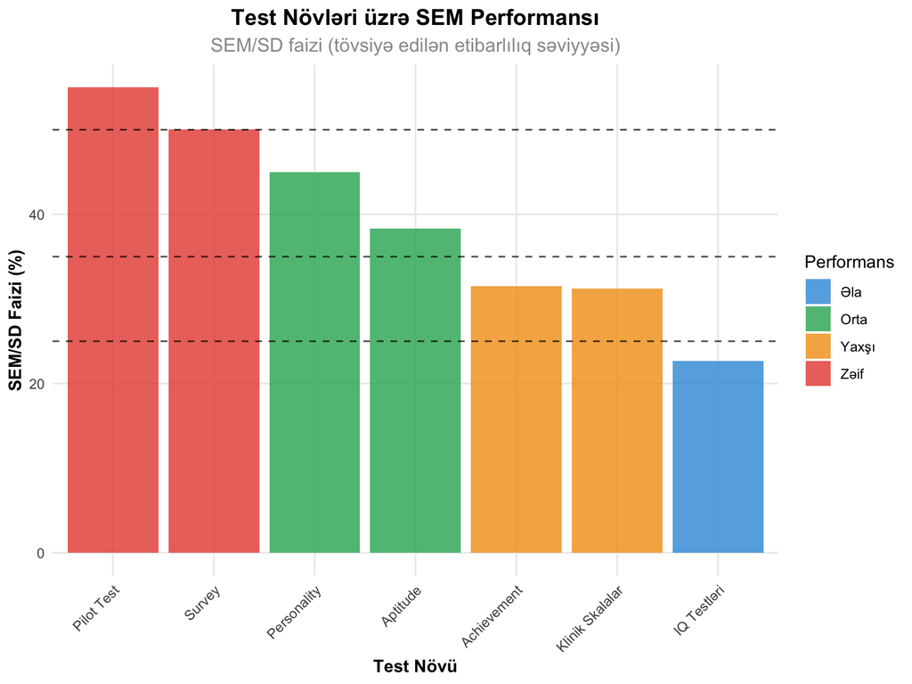

```r
# Test performansının vizuallaşdırılması
performance_data <- data.frame(
  Test = test_types$Test_Növü,
  SEM_Percentage = test_types$SEM_Faizi_Töv,
  Category = ifelse(test_types$SEM_Faizi_Töv < 25, "Əla",
                   ifelse(test_types$SEM_Faizi_Töv < 35, "Yaxşı",
                         ifelse(test_types$SEM_Faizi_Töv < 50, "Orta", "Zəif")))
)

ggplot(performance_data, aes(x = reorder(Test, -SEM_Percentage), y = SEM_Percentage, fill = Category)) +
  geom_col(alpha = 0.8) +
  geom_hline(yintercept = c(25, 35, 50), linetype = "dashed", alpha = 0.7) +
  scale_fill_manual(values = c("Əla" = colors_basic[1], "Yaxşı" = colors_basic[3],
                               "Orta" = colors_basic[4], "Zəif" = colors_basic[2])) +
  labs(title = "Test Növləri üzrə SEM Performansı",
       subtitle = "SEM/SD faizi (tövsiyə edilən etibarlılıq səviyyəsi)",
       x = "Test Növü", y = "SEM/SD Faizi (%)",
       fill = "Performans") +
  theme_clean() +
  theme(axis.text.x = element_text(angle = 45, hjust = 1))
```

# 4 Praktiki Tətbiqlər və Nümunələr

## 4.1 Klinik və Təhsil Sahələrində SEM

```r
cat("=== KLİNİK VƏ TƏHSİL SAHƏLƏRİNDƏ SEM ===\n\n")
```

```
## === KLİNİK VƏ TƏHSİL SAHƏLƏRİNDƏ SEM ===
```

```r
# Klinik nümunə: Depressiya skalası
clinical_example <- function() {
  cat("KLİNİK NÜMUNƏ - DEPRESSIYA SKALASI:\n")

  # Beck Depression Inventory nümunəsi
  bdi_score <- 18  # Hafif depressiya
  bdi_mean <- 5    # Normal populyasiya ortası
  bdi_sd <- 8      # Standart sapma
  bdi_reliability <- 0.92
  bdi_sem <- bdi_sd * sqrt(1 - bdi_reliability)

  # Güven aralıqları
  ci_95 <- c(bdi_score - 1.96 * bdi_sem, bdi_score + 1.96 * bdi_sem)

  cat("Patient balı:", bdi_score, "\n")
  cat("SEM:", round(bdi_sem, 2), "\n")
  cat("95% güven aralığı:", round(ci_95[1], 1), "-", round(ci_95[2], 1), "\n")

  # Klinik interpretasiya
  if(ci_95[1] > 13) {
    cat("Qərar: Klinik əhəmiyyətli depressiya (95% güvənlə)\n")
  } else if(ci_95[2] < 13) {
    cat("Qərar: Klinik əhəmiyyətli depressiya yoxdur (95% güvənlə)\n")
  } else {
    cat("Qərar: Əlavə qiymətləndirmə lazımdır\n")
  }

  return(list(score = bdi_score, sem = bdi_sem, ci = ci_95))
}

clinical_result <- clinical_example()
```

```
## KLİNİK NÜMUNƏ - DEPRESSIYA SKALASI:
## Patient balı: 18
## SEM: 2.26
## 95% güven aralığı: 13.6 - 22.4
## Qərar: Klinik əhəmiyyətli depressiya (95% güvənlə)
```

```r
cat("\n")
```

```r
# Təhsil nümunəsi: Standardlaşdırılmış test
educational_example <- function() {
  cat("TƏHSİL NÜMUNƏSI - STANDARDLAŞDIRILMIŞ TEST:\n")

  # SAT nümunəsi
  sat_score <- 1280
  sat_mean <- 1060
  sat_sd <- 195
  sat_reliability <- 0.88
  sat_sem <- sat_sd * sqrt(1 - sat_reliability)

  # Güven aralıqları
  ci_95 <- c(sat_score - 1.96 * sat_sem, sat_score + 1.96 * sat_sem)

  cat("Student balı:", sat_score, "\n")
  cat("SEM:", round(sat_sem, 0), "\n")
  cat("95% güven aralığı:", round(ci_95[1], 0), "-", round(ci_95[2], 0), "\n")

  # College admission threshold
  threshold <- 1200
  if(ci_95[1] > threshold) {
    cat("Qərar: Admission threshold-u keçir (95% güvənlə)\n")
  } else if(ci_95[2] < threshold) {
    cat("Qərar: Admission threshold-u keçmir (95% güvənlə)\n")
  } else {
    cat("Qərar: Threshold ətrafında, əlavə məlumat lazımdır\n")
  }

  return(list(score = sat_score, sem = sat_sem, ci = ci_95))
}

educational_result <- educational_example()
```

```
## TƏHSİL NÜMUNƏSI - STANDARDLAŞDIRILMIŞ TEST:
## Student balı: 1280
## SEM: 68
## 95% güven aralığı: 1148 - 1412
## Qərar: Threshold ətrafında, əlavə məlumat lazımdır
```

```r
cat("\n")
```

```r
# Practical applications cədvəli
practical_applications <- data.frame(
  Sahə = c("Klinik Psixologiya", "Təhsil Qiymətləndirmə", "İş Seçimi",
           "Lisenziya İmtahanları", "Tədqiqat"),
  SEM_İstifadəsi = c("Diaqnoz dəqiqliyi", "Student progress", "İş uyğunluğu",
                     "Keçid qərarları", "Effekt ölçüsü"),
  Tipik_SEM = c("1-3 bal", "5-15 bal", "3-8 bal", "2-5 bal", "Dəyişkən"),
  Kritik_Qərar = c("Müalicə planı", "Sertifikat verilməsi", "İşə qəbul",
                   "Lisenziya", "Nəticə interpretasiyası"),
  Güven_Səviyyəsi = c("95-99%", "90-95%", "90-95%", "95-99%", "95%")
)

kable(practical_applications, caption = "Müxtəlif Sahələrdə SEM-in Praktiki İstifadəsi")
```

Müxtəlif Sahələrdə SEM-in Praktiki İstifadəsi

| Sahə | SEM_İstifadəsi | Tipik_SEM | Kritik_Qərar | Güven_Səviyyəsi |
| --- | --- | --- | --- | --- |
| Klinik Psixologiya | Diaqnoz dəqiqliyi | 1-3 bal | Müalicə planı | 95-99% |
| Təhsil Qiymətləndirmə | Student progress | 5-15 bal | Sertifikat verilməsi | 90-95% |
| İş Seçimi | İş uyğunluğu | 3-8 bal | İşə qəbul | 90-95% |
| Lisenziya İmtahanları | Keçid qərarları | 2-5 bal | Lisenziya | 95-99% |
| Tədqiqat | Effekt ölçüsü | Dəyişkən | Nəticə interpretasiyası | 95% |

## 4.2 SEM və Proqnoz Modelləri

```r
cat("=== SEM VƏ PROQNOZ MODELLƏRİ ===\n\n")
```

```
## === SEM VƏ PROQNOZ MODELLƏRİ ===
```

```r
# Regression to the mean və SEM
regression_to_mean_demo <- function(initial_scores, reliability) {
  population_mean <- 100
  sem <- sd(initial_scores) * sqrt(1 - reliability)

  # Predicted true scores
  predicted_true <- population_mean + reliability * (initial_scores - population_mean)

  # Expected retest scores (regression to mean)
  expected_retest <- predicted_true

  # SEM confidence intervals for retest
  ci_lower <- expected_retest - 1.96 * sem
  ci_upper <- expected_retest + 1.96 * sem

  return(data.frame(
    Initial_Score = initial_scores,
    Predicted_True = round(predicted_true, 1),
    Expected_Retest = round(expected_retest, 1),
    CI_Lower = round(ci_lower, 1),
    CI_Upper = round(ci_upper, 1),
    SEM = round(rep(sem, length(initial_scores)), 2)
  ))
}

# Nümunə ballar
sample_scores <- c(130, 120, 110, 90, 80, 70)
reliability_level <- 0.85

regression_results <- regression_to_mean_demo(sample_scores, reliability_level)

cat("REGRESSION TO THE MEAN VƏ SEM ANALİZİ:\n")
```

```
## REGRESSION TO THE MEAN VƏ SEM ANALİZİ:
```

```r
cat("Test etibarlılığı:", reliability_level, "\n")
```

```
## Test etibarlılığı: 0.85
```

```r
cat("SEM:", round(sd(sample_scores) * sqrt(1 - reliability_level), 2), "\n\n")
```

```
## SEM: 9.17
```

```r
kable(regression_results, caption = "Yenidən Test Proqnozları və SEM Güven Aralıqları")
```

Yenidən Test Proqnozları və SEM Güven Aralıqları

| Initial_Score | Predicted_True | Expected_Retest | CI_Lower | CI_Upper | SEM |
| --- | --- | --- | --- | --- | --- |
| 130 | 125.5 | 125.5 | 107.5 | 143.5 | 9.17 |
| 120 | 117.0 | 117.0 | 99.0 | 135.0 | 9.17 |
| 110 | 108.5 | 108.5 | 90.5 | 126.5 | 9.17 |
| 90 | 91.5 | 91.5 | 73.5 | 109.5 | 9.17 |
| 80 | 83.0 | 83.0 | 65.0 | 101.0 | 9.17 |
| 70 | 74.5 | 74.5 | 56.5 | 92.5 | 9.17 |

```r
# SEM və reliable change index (RCI)
reliable_change_analysis <- function(pre_score, post_score, sem) {
  # Reliable Change Index
  rci <- (post_score - pre_score) / (sqrt(2) * sem)

  # Critical values for reliable change
  critical_90 <- 1.645  # 90% confidence
  critical_95 <- 1.96   # 95% confidence
  critical_99 <- 2.58   # 99% confidence

  # Interpretations
  reliable_90 <- abs(rci) >= critical_90
  reliable_95 <- abs(rci) >= critical_95
  reliable_99 <- abs(rci) >= critical_99

  direction <- ifelse(rci > 0, "Yaxşılaşma", ifelse(rci < 0, "Pisləşmə", "Dəyişiklik yox"))

  return(list(
    rci = rci,
    direction = direction,
    reliable_90 = reliable_90,
    reliable_95 = reliable_95,
    reliable_99 = reliable_99
  ))
}

# RCI nümunələri
cat("\nRELIABLE CHANGE INDEX (RCI) ANALİZİ:\n")
```

```
##
## RELIABLE CHANGE INDEX (RCI) ANALİZİ:
```

```r
rci_examples <- data.frame(
  Patient = c("A", "B", "C", "D", "E"),
  Pre_Test = c(25, 18, 30, 22, 15),
  Post_Test = c(15, 16, 28, 12, 8),
  Change = c(-10, -2, -2, -10, -7)
)

# RCI hesablama (SEM = 3 fərz edək)
example_sem <- 3
rci_examples$RCI <- round(rci_examples$Change / (sqrt(2) * example_sem), 2)
rci_examples$Reliable_95 <- abs(rci_examples$RCI) >= 1.96
rci_examples$Interpretation <- ifelse(rci_examples$RCI <= -1.96, "Əhəmiyyətli yaxşılaşma",
                                     ifelse(rci_examples$RCI >= 1.96, "Əhəmiyyətli pisləşmə",
                                           "Dəyişiklik yox"))

kable(rci_examples, caption = "Reliable Change Index Nümunələri (SEM = 3)")
```

Reliable Change Index Nümunələri (SEM = 3)

| Patient | Pre_Test | Post_Test | Change | RCI | Reliable_95 | Interpretation |
| --- | --- | --- | --- | --- | --- | --- |
| A | 25 | 15 | -10 | -2.36 | TRUE | Əhəmiyyətli yaxşılaşma |
| B | 18 | 16 | -2 | -0.47 | FALSE | Dəyişiklik yox |
| C | 30 | 28 | -2 | -0.47 | FALSE | Dəyişiklik yox |
| D | 22 | 12 | -10 | -2.36 | TRUE | Əhəmiyyətli yaxşılaşma |
| E | 15 | 8 | -7 | -1.65 | FALSE | Dəyişiklik yox |

```r
cat("RCI İNTERPRETASİYA PRİNSİPLƏRİ:\n")
```

```
## RCI İNTERPRETASİYA PRİNSİPLƏRİ:
```

```r
rci_principles <- c(
  "• RCI = (Post - Pre) / (√2 × SEM)",
  "• |RCI| ≥ 1.96 = 95% güvənlə əhəmiyyətli dəyişiklik",
  "• Mənfi RCI = yaxşılaşma (əgər aşağı bal yaxşıdırsa)",
  "• Müsbət RCI = pisləşmə (əgər aşağı bal yaxşıdırsa)",
  "• Kiçik SEM = daha həssas dəyişiklik təyini"
)

for(principle in rci_principles) {
  cat(principle, "\n")
}
```

```
## • RCI = (Post - Pre) / (√2 × SEM)
## • |RCI| ≥ 1.96 = 95% güvənlə əhəmiyyətli dəyişiklik
## • Mənfi RCI = yaxşılaşma (əgər aşağı bal yaxşıdırsa)
## • Müsbət RCI = pisləşmə (əgər aşağı bal yaxşıdırsa)
## • Kiçik SEM = daha həssas dəyişiklik təyini
```

# 5 Praktiki Tapşırıqlar

## 5.1 Tapşırıq 1: Müxtəlif Etibarlılıq Səviyyələri üçün SEM

```r
cat("=== TAPŞıRıQ 1: MÜXTƏLİF ETİBARLILIQ SƏVİYYƏLƏRİ ÜÇÜN SEM ===\n\n")
```

```
## === TAPŞıRıQ 1: MÜXTƏLİF ETİBARLILIQ SƏVİYYƏLƏRİ ÜÇÜN SEM ===
```

```r
# Test ssenariləri yaratma
create_sem_scenarios <- function() {
  set.seed(2025)

  scenarios <- list()

  # Ssenari 1: IQ Testi
  scenarios$iq_test <- list(
    name = "IQ Testi",
    mean = 100,
    sd = 15,
    reliability_levels = c(0.90, 0.92, 0.95, 0.97),
    interpretation_range = "Fərdi qərarlar üçün"
  )

  # Ssenari 2: Achievement Test
  scenarios$achievement <- list(
    name = "Achievement Test",
    mean = 250,
    sd = 40,
    reliability_levels = c(0.80, 0.85, 0.88, 0.92),
    interpretation_range = "Təhsil qiymətləndirmə"
  )

  # Ssenari 3: Personality Scale
  scenarios$personality <- list(
    name = "Şəxsiyyət Skalası",
    mean = 50,
    sd = 10,
    reliability_levels = c(0.70, 0.75, 0.80, 0.85),
    interpretation_range = "Tədqiqat məqsədləri"
  )

  # Ssenari 4: Clinical Scale
  scenarios$clinical <- list(
    name = "Klinik Skala",
    mean = 0,
    sd = 8,
    reliability_levels = c(0.85, 0.90, 0.93, 0.96),
    interpretation_range = "Klinik qərarlar"
  )

  return(scenarios)
}

sem_scenarios <- create_sem_scenarios()

cat("TAPŞıRıQ 1: Aşağıdakı test ssenariləri üçün SEM analizi aparın:\n\n")
```

```
## TAPŞıRıQ 1: Aşağıdakı test ssenariləri üçün SEM analizi aparın:
```

```r
# Ssenari təsviri
for(i in 1:length(sem_scenarios)) {
  scenario <- sem_scenarios[[i]]
  cat(paste(i, ". ", scenario$name, ":\n", sep = ""))
  cat("   Orta:", scenario$mean, ", SD:", scenario$sd, "\n")
  cat("   Etibarlılıq səviyyələri:", paste(scenario$reliability_levels, collapse = ", "), "\n")
  cat("   İstifadə sahəsi:", scenario$interpretation_range, "\n\n")
}
```

```
## 1. IQ Testi:
##    Orta: 100 , SD: 15
##    Etibarlılıq səviyyələri: 0.9, 0.92, 0.95, 0.97
##    İstifadə sahəsi: Fərdi qərarlar üçün
##
## 2. Achievement Test:
##    Orta: 250 , SD: 40
##    Etibarlılıq səviyyələri: 0.8, 0.85, 0.88, 0.92
##    İstifadə sahəsi: Təhsil qiymətləndirmə
##
## 3. Şəxsiyyət Skalası:
##    Orta: 50 , SD: 10
##    Etibarlılıq səviyyələri: 0.7, 0.75, 0.8, 0.85
##    İstifadə sahəsi: Tədqiqat məqsədləri
##
## 4. Klinik Skala:
##    Orta: 0 , SD: 8
##    Etibarlılıq səviyyələri: 0.85, 0.9, 0.93, 0.96
##    İstifadə sahəsi: Klinik qərarlar
```

```r
cat("TAPŞıRıQ TƏLİMATLARI:\n")
```

```
## TAPŞıRıQ TƏLİMATLARI:
```

```r
cat("1. Hər ssenari üçün SEM hesablayın\n")
```

```
## 1. Hər ssenari üçün SEM hesablayın
```

```r
cat("2. SEM/SD nisbətini hesablayın\n")
```

```
## 2. SEM/SD nisbətini hesablayın
```

```r
cat("3. Optimal etibarlılıq səviyyəsini müəyyən edin\n")
```

```
## 3. Optimal etibarlılıq səviyyəsini müəyyən edin
```

```r
cat("4. Praktiki tövsiyələr verin\n\n")
```

```
## 4. Praktiki tövsiyələr verin
```

```r
# Nümunə analiz (IQ Test)
cat("NÜMUNƏ ANALİZ (IQ Testi):\n")
```

```
## NÜMUNƏ ANALİZ (IQ Testi):
```

```r
scenario1 <- sem_scenarios$iq_test
sem_values <- scenario1$sd * sqrt(1 - scenario1$reliability_levels)
sem_percentages <- 100 * sem_values / scenario1$sd

sample_analysis <- data.frame(
  Etibarlılıq = scenario1$reliability_levels,
  SEM = round(sem_values, 1),
  SEM_Faizi = round(sem_percentages, 1),
  Qiymət = ifelse(sem_percentages < 25, "Əla",
                 ifelse(sem_percentages < 35, "Yaxşı", "Qəbul edilə bilər")),
  Tövsiyə = ifelse(sem_percentages < 25, "Fərdi qərarlar üçün ideal",
                  ifelse(sem_percentages < 35, "Klinik istifadə uyğun", "Yalnız qrup üçün"))
)

kable(sample_analysis, caption = "IQ Testi SEM Analizi")
```

IQ Testi SEM Analizi

| Etibarlılıq | SEM | SEM_Faizi | Qiymət | Tövsiyə |
| --- | --- | --- | --- | --- |
| 0.90 | 4.7 | 31.6 | Yaxşı | Klinik istifadə uyğun |
| 0.92 | 4.2 | 28.3 | Yaxşı | Klinik istifadə uyğun |
| 0.95 | 3.4 | 22.4 | Əla | Fərdi qərarlar üçün ideal |
| 0.97 | 2.6 | 17.3 | Əla | Fərdi qərarlar üçün ideal |

## 5.2 Tapşırıq 2: Fərdi Bal İnterpretasiyası

```r
cat("=== TAPŞıRıQ 2: FƏRDİ BAL İNTERPRETASİYASI ===\n\n")
```

```
## === TAPŞıRıQ 2: FƏRDİ BAL İNTERPRETASİYASI ===
```

```r
# Fərdi ballar üçün ssenari
individual_cases <- data.frame(
  Student = c("Ayşe", "Mübariz", "Leyla", "Rəşad", "Gülnar"),
  Test_Balı = c(115, 88, 102, 135, 76),
  Test_Növü = c("IQ", "Achievement", "IQ", "IQ", "Achievement"),
  Test_SD = c(15, 20, 15, 15, 20),
  Etibarlılıq = c(0.92, 0.85, 0.90, 0.95, 0.82),
  Məqsəd = c("Gifted program", "Remedial help", "School placement",
             "Advanced program", "Support services")
)

# SEM hesablama
individual_cases$SEM <- round(individual_cases$Test_SD * sqrt(1 - individual_cases$Etibarlılıq), 1)

kable(individual_cases, caption = "Tapşırıq 2 - Fərdi Bal Ssenariləri")
```

Tapşırıq 2 - Fərdi Bal Ssenariləri

| Student | Test_Balı | Test_Növü | Test_SD | Etibarlılıq | Məqsəd | SEM |
| --- | --- | --- | --- | --- | --- | --- |
| Ayşe | 115 | IQ | 15 | 0.92 | Gifted program | 4.2 |
| Mübariz | 88 | Achievement | 20 | 0.85 | Remedial help | 7.7 |
| Leyla | 102 | IQ | 15 | 0.90 | School placement | 4.7 |
| Rəşad | 135 | IQ | 15 | 0.95 | Advanced program | 3.4 |
| Gülnar | 76 | Achievement | 20 | 0.82 | Support services | 8.5 |

```r
cat("TAPŞıRıQ TƏLİMATLARI:\n")
```

```
## TAPŞıRıQ TƏLİMATLARI:
```

```r
cat("1. Hər student üçün 95% güven aralığı hesablayın\n")
```

```
## 1. Hər student üçün 95% güven aralığı hesablayın
```

```r
cat("2. Z-score və persentil təyin edin\n")
```

```
## 2. Z-score və persentil təyin edin
```

```r
cat("3. Qərar threshold-ları ilə müqayisə edin\n")
```

```
## 3. Qərar threshold-ları ilə müqayisə edin
```

```r
cat("4. Praktiki tövsiyələr hazırlayın\n\n")
```

```
## 4. Praktiki tövsiyələr hazırlayın
```

```r
# Threshold-lar
thresholds <- data.frame(
  Proqram = c("Gifted (IQ)", "Average (IQ)", "Below Average (IQ)",
              "Proficient (Achievement)", "Basic (Achievement)"),
  Threshold = c(130, 100, 85, 75, 50),
  Mənası = c("2+ SD yuxarı", "Orta", "1+ SD aşağı", "Yetərli səviyyə", "Əsas səviyyə")
)

kable(thresholds, caption = "Qərar Threshold-ları")
```

Qərar Threshold-ları

| Proqram | Threshold | Mənası |
| --- | --- | --- |
| Gifted (IQ) | 130 | 2+ SD yuxarı |
| Average (IQ) | 100 | Orta |
| Below Average (IQ) | 85 | 1+ SD aşağı |
| Proficient (Achievement) | 75 | Yetərli səviyyə |
| Basic (Achievement) | 50 | Əsas səviyyə |

```r
# Nümunə interpretasiya (Ayşe)
cat("NÜMUNƏ İNTERPRETASİYA (Ayşe):\n")
```

```
## NÜMUNƏ İNTERPRETASİYA (Ayşe):
```

```r
ayse_score <- 115
ayse_sem <- individual_cases[1, "SEM"]
ayse_ci <- c(ayse_score - 1.96 * ayse_sem, ayse_score + 1.96 * ayse_sem)

cat("Bal:", ayse_score, "\n")
```

```
## Bal: 115
```

```r
cat("SEM:", ayse_sem, "\n")
```

```
## SEM: 4.2
```

```r
cat("95% CI:", round(ayse_ci[1], 1), "-", round(ayse_ci[2], 1), "\n")
```

```
## 95% CI: 106.8 - 123.2
```

```r
cat("Gifted threshold (130):", ifelse(ayse_ci[1] > 130, "Keçir",
                                     ifelse(ayse_ci[2] < 130, "Keçmir", "Qeyri-müəyyən")), "\n\n")
```

```
## Gifted threshold (130): Keçmir
```

## 5.3 Tapşırıq 3: SEM və Reliable Change

```r
cat("=== TAPŞıRıQ 3: SEM VƏ RELİABLE CHANGE ===\n\n")
```

```
## === TAPŞıRıQ 3: SEM VƏ RELİABLE CHANGE ===
```

```r
# Pre-post intervention ssenariləri
intervention_data <- data.frame(
  Participant = paste0("P", 1:8),
  Pre_Test = c(28, 35, 22, 41, 19, 33, 26, 38),
  Post_Test = c(18, 30, 20, 35, 12, 28, 22, 31),
  Intervention = c("CBT", "CBT", "Medication", "CBT", "Medication",
                   "Combined", "Combined", "Control"),
  Test_SD = rep(8, 8),
  Reliability = rep(0.88, 8)
)

# SEM hesablama
intervention_data$SEM <- round(intervention_data$Test_SD * sqrt(1 - intervention_data$Reliability), 1)
intervention_data$Change <- intervention_data$Post_Test - intervention_data$Pre_Test

kable(intervention_data, caption = "Tapşırıq 3 - Müdaxilə Araşdırması Məlumatları")
```

Tapşırıq 3 - Müdaxilə Araşdırması Məlumatları

| Participant | Pre_Test | Post_Test | Intervention | Test_SD | Reliability | SEM | Change |
| --- | --- | --- | --- | --- | --- | --- | --- |
| P1 | 28 | 18 | CBT | 8 | 0.88 | 2.8 | -10 |
| P2 | 35 | 30 | CBT | 8 | 0.88 | 2.8 | -5 |
| P3 | 22 | 20 | Medication | 8 | 0.88 | 2.8 | -2 |
| P4 | 41 | 35 | CBT | 8 | 0.88 | 2.8 | -6 |
| P5 | 19 | 12 | Medication | 8 | 0.88 | 2.8 | -7 |
| P6 | 33 | 28 | Combined | 8 | 0.88 | 2.8 | -5 |
| P7 | 26 | 22 | Combined | 8 | 0.88 | 2.8 | -4 |
| P8 | 38 | 31 | Control | 8 | 0.88 | 2.8 | -7 |

```r
cat("TAPŞıRıQ TƏLİMATLARI:\n")
```

```
## TAPŞıRıQ TƏLİMATLARI:
```

```r
cat("1. Hər iştirakçı üçün RCI hesablayın\n")
```

```
## 1. Hər iştirakçı üçün RCI hesablayın
```

```r
cat("2. Reliable change müəyyən edin (95% güven)\n")
```

```
## 2. Reliable change müəyyən edin (95% güven)
```

```r
cat("3. Müdaxilə qruplarını müqayisə edin\n")
```

```
## 3. Müdaxilə qruplarını müqayisə edin
```

```r
cat("4. Klinik əhəmiyyət qiymətləndirin\n\n")
```

```
## 4. Klinik əhəmiyyət qiymətləndirin
```

```r
# RCI formula və interpretasiya
cat("RCI FORMULA VƏ İNTERPRETASİYA:\n")
```

```
## RCI FORMULA VƏ İNTERPRETASİYA:
```

```r
cat("RCI = (Post - Pre) / (√2 × SEM)\n")
```

```
## RCI = (Post - Pre) / (√2 × SEM)
```

```r
cat("Reliable change kriteriləri:\n")
```

```
## Reliable change kriteriləri:
```

```r
cat("• |RCI| ≥ 1.96 = 95% güvənlə əhəmiyyətli dəyişiklik\n")
```

```
## • |RCI| ≥ 1.96 = 95% güvənlə əhəmiyyətli dəyişiklik
```

```r
cat("• |RCI| ≥ 1.645 = 90% güvənlə əhəmiyyətli dəyişiklik\n\n")
```

```
## • |RCI| ≥ 1.645 = 90% güvənlə əhəmiyyətli dəyişiklik
```

```r
# Nümunə hesablama (P1)
p1_rci <- intervention_data$Change[1] / (sqrt(2) * intervention_data$SEM[1])
cat("NÜMUNƏ HESABLAMA (P1):\n")
```

```
## NÜMUNƏ HESABLAMA (P1):
```

```r
cat("Change:", intervention_data$Change[1], "\n")
```

```
## Change: -10
```

```r
cat("SEM:", intervention_data$SEM[1], "\n")
```

```
## SEM: 2.8
```

```r
cat("RCI = ", intervention_data$Change[1], "/ (√2 ×", intervention_data$SEM[1], ") =", round(p1_rci, 2), "\n")
```

```
## RCI =  -10 / (√2 × 2.8 ) = -2.53
```

```r
cat("95% əhəmiyyətli:", ifelse(abs(p1_rci) >= 1.96, "Bəli", "Xeyr"), "\n\n")
```

```
## 95% əhəmiyyətli: Bəli
```

## 5.4 Tapşırıq 4: SEM Əsaslı Test Təkmilləşdirmə

```r
cat("=== TAPŞıRıQ 4: SEM ƏSASLI TEST TƏKMİLLƏŞDİRMƏ ===\n\n")
```

```
## === TAPŞıRıQ 4: SEM ƏSASLI TEST TƏKMİLLƏŞDİRMƏ ===
```

```r
# Test inkişaf ssenariləri
test_development_scenarios <- data.frame(
  Version = c("Pilot", "Beta", "Final", "Target"),
  Items = c(25, 40, 50, 60),
  Current_Alpha = c(0.65, 0.78, 0.85, NA),
  Test_SD = c(12, 15, 18, 20),
  Target_SEM = c(NA, NA, NA, 3),
  Purpose = c("İlkin test", "Field test", "Operational", "İdeal versiya")
)

# Mövcud SEM hesablama
test_development_scenarios$Current_SEM <- ifelse(
  is.na(test_development_scenarios$Current_Alpha), NA,
  round(test_development_scenarios$Test_SD * sqrt(1 - test_development_scenarios$Current_Alpha), 1)
)

# Target reliability hesablama
target_sem <- 3
target_sd <- 20
target_reliability <- 1 - (target_sem / target_sd)^2
test_development_scenarios$Target_Alpha[4] <- round(target_reliability, 3)

kable(test_development_scenarios, caption = "Tapşırıq 4 - Test İnkişaf Ssenariləri")
```

Tapşırıq 4 - Test İnkişaf Ssenariləri

| Version | Items | Current_Alpha | Test_SD | Target_SEM | Purpose | Current_SEM | Target_Alpha |
| --- | --- | --- | --- | --- | --- | --- | --- |
| Pilot | 25 | 0.65 | 12 | NA | İlkin test | 7.1 | NA |
| Beta | 40 | 0.78 | 15 | NA | Field test | 7.0 | NA |
| Final | 50 | 0.85 | 18 | NA | Operational | 7.0 | NA |
| Target | 60 | NA | 20 | 3 | İdeal versiya | NA | 0.978 |

```r
cat("TAPŞıRıQ TƏLİMATLARI:\n")
```

```
## TAPŞıRıQ TƏLİMATLARI:
```

```r
cat("1. Hər versiya üçün SEM/SD nisbətini hesablayın\n")
```

```
## 1. Hər versiya üçün SEM/SD nisbətini hesablayın
```

```r
cat("2. Target SEM üçün lazım olan etibarlılığı təyin edin\n")
```

```
## 2. Target SEM üçün lazım olan etibarlılığı təyin edin
```

```r
cat("3. Test uzunluğu artımının təsirini proqnozlaşdırın\n")
```

```
## 3. Test uzunluğu artımının təsirini proqnozlaşdırın
```

```r
cat("4. İnkişaf strategiyası təklif edin\n\n")
```

```
## 4. İnkişaf strategiyası təklif edin
```

```r
# Spearman-Brown ilə test uzunluğu proqnozu
spearman_brown_prediction <- function(current_alpha, length_ratio) {
  predicted_alpha <- (length_ratio * current_alpha) / (1 + (length_ratio - 1) * current_alpha)
  return(predicted_alpha)
}

cat("TEST UZUNLUĞU PROQNOZLAŞDırıLMASI:\n")
```

```
## TEST UZUNLUĞU PROQNOZLAŞDırıLMASI:
```

```r
# Current beta version improvement
current_alpha <- 0.78
current_items <- 40
target_items <- c(50, 60, 80, 100)

improvement_predictions <- data.frame(
  Target_Items = target_items,
  Length_Ratio = target_items / current_items,
  Predicted_Alpha = round(sapply(target_items / current_items,
                                function(x) spearman_brown_prediction(current_alpha, x)), 3)
)

improvement_predictions$Predicted_SEM <- round(15 * sqrt(1 - improvement_predictions$Predicted_Alpha), 1)
improvement_predictions$SEM_Improvement <- round(15 * sqrt(1 - current_alpha) - improvement_predictions$Predicted_SEM, 1)

kable(improvement_predictions, caption = "Beta Versiyasından İnkişaf Proqnozları")
```

Beta Versiyasından İnkişaf Proqnozları

| Target_Items | Length_Ratio | Predicted_Alpha | Predicted_SEM | SEM_Improvement |
| --- | --- | --- | --- | --- |
| 50 | 1.25 | 0.816 | 6.4 | 0.6 |
| 60 | 1.50 | 0.842 | 6.0 | 1.0 |
| 80 | 2.00 | 0.876 | 5.3 | 1.7 |
| 100 | 2.50 | 0.899 | 4.8 | 2.2 |

```r
cat("İNKİŞAF STRATEGİYALARI:\n")
```

```
## İNKİŞAF STRATEGİYALARI:
```

```r
development_strategies <- c(
  "• Test uzunluğunu artırın (Spearman-Brown)",
  "• Zəif bəndləri çıxarın və yeni bəndlər əlavə edin",
  "• Bənd-total korrelyasiyasını yaxşılaşdırın",
  "• Target populyasiya üçün bəndləri optimallaşdırın",
  "• Pilot testlərdə məlumat toplayın və təhlil edin"
)

for(strategy in development_strategies) {
  cat(strategy, "\n")
}
```

```
## • Test uzunluğunu artırın (Spearman-Brown)
## • Zəif bəndləri çıxarın və yeni bəndlər əlavə edin
## • Bənd-total korrelyasiyasını yaxşılaşdırın
## • Target populyasiya üçün bəndləri optimallaşdırın
## • Pilot testlərdə məlumat toplayın və təhlil edin
```

```r
# Test improvement recommendations
cat("\nTEST TƏKMİLLƏŞDİRMƏ TÖVSİYƏLƏRİ:\n")
```

```
##
## TEST TƏKMİLLƏŞDİRMƏ TÖVSİYƏLƏRİ:
```

```r
improvement_recommendations <- data.frame(
  Current_SEM = c("6-8", "4-6", "3-4", "2-3", "<2"),
  Priority = c("Yüksək", "Orta-Yüksək", "Orta", "Aşağı", "Saxla"),
  Action = c("Əsaslı yenidən dizayn", "Bənd əlavəsi/dəyişikliyi", "Kiçik təkmilləşdirmə",
             "İzləmə", "Mövcud versiya yaxşıdır"),
  Timeline = c("6-12 ay", "3-6 ay", "1-3 ay", "Davam edən", "N/A"),
  Resources = c("Böyük", "Orta", "Kiçik", "Minimal", "Yox")
)

kable(improvement_recommendations, caption = "SEM Əsaslı Test Təkmilləşdirmə Tövsiyələri")
```

SEM Əsaslı Test Təkmilləşdirmə Tövsiyələri

| Current_SEM | Priority | Action | Timeline | Resources |
| --- | --- | --- | --- | --- |
| 6-8 | Yüksək | Əsaslı yenidən dizayn | 6-12 ay | Böyük |
| 4-6 | Orta-Yüksək | Bənd əlavəsi/dəyişikliyi | 3-6 ay | Orta |
| 3-4 | Orta | Kiçik təkmilləşdirmə | 1-3 ay | Kiçik |
| 2-3 | Aşağı | İzləmə | Davam edən | Minimal |
| <2 | Saxla | Mövcud versiya yaxşıdır | N/A | Yox |

# 6 Dərsin Xülasəsi

## 6.1 Əsas Nəticələr

```r
cat("=== DƏRSIN ƏSAS NƏTİCƏLƏRİ ===\n\n")
```

```
## === DƏRSIN ƏSAS NƏTİCƏLƏRİ ===
```

```r
# Əsas konseptlər xülasəsi
key_concepts_sem <- data.frame(
  Konsept = c("SEM Mahiyyəti", "SEM Formulası", "Etibarlılıq Əlaqəsi",
              "Güven Aralıqları", "Reliable Change"),
  Əsas_Məzmun = c("Xətanın standart sapması",
                  "SEM = σₓ√(1-ρₓₓ)",
                  "Yüksək r → Aşağı SEM",
                  "Fərdi bal dəqiqliyi",
                  "Pre-post dəyişiklik qiymətləndirmə"),
  Öyrənilən_Bacarıq = c("Konseptual anlayış", "Manual hesablama", "Əlaqə anlayışı",
                        "İnterpretasiya", "Dəyişiklik analizi"),
  Praktiki_Tətbiq = c("Xəta qiymətləndirmə", "Test performansı", "Test seçimi",
                      "Fərdi qərarlar", "Müdaxilə effektivliyi")
)

kable(key_concepts_sem, caption = "SEM Dərsində Öyrənilən Əsas Konseptlər")
```

SEM Dərsində Öyrənilən Əsas Konseptlər

| Konsept | Əsas_Məzmun | Öyrənilən_Bacarıq | Praktiki_Tətbiq |
| --- | --- | --- | --- |
| SEM Mahiyyəti | Xətanın standart sapması | Konseptual anlayış | Xəta qiymətləndirmə |
| SEM Formulası | SEM = σₓ√(1-ρₓₓ) | Manual hesablama | Test performansı |
| Etibarlılıq Əlaqəsi | Yüksək r → Aşağı SEM | Əlaqə anlayışı | Test seçimi |
| Güven Aralıqları | Fərdi bal dəqiqliyi | İnterpretasiya | Fərdi qərarlar |
| Reliable Change | Pre-post dəyişiklik qiymətləndirmə | Dəyişiklik analizi | Müdaxilə effektivliyi |

```r
# Qazanılan praktiki bacarıqlar
practical_skills_sem <- c(
  "✓ SEM əmsalını manual hesablama",
  "✓ SEM və etibarlılıq əlaqəsini anlama",
  "✓ Fərdi ballar üçün güven aralıqları hesablama",
  "✓ Reliable Change Index (RCI) hesablama və interpretasiya",
  "✓ SEM əsaslı qərar vermə",
  "✓ Test performansını SEM ilə qiymətləndirmə",
  "✓ SEM əsaslı test təkmilləşdirmə strategiyaları",
  "✓ Klinik və təhsil kontekstində SEM tətbiqi"
)

cat("QAZANILAN PRaktiki bacarıqlar:\n")
```

```
## QAZANILAN PRaktiki bacarıqlar:
```

```r
for(skill in practical_skills_sem) {
  cat(skill, "\n")
}
```

```
## ✓ SEM əmsalını manual hesablama
## ✓ SEM və etibarlılıq əlaqəsini anlama
## ✓ Fərdi ballar üçün güven aralıqları hesablama
## ✓ Reliable Change Index (RCI) hesablama və interpretasiya
## ✓ SEM əsaslı qərar vermə
## ✓ Test performansını SEM ilə qiymətləndirmə
## ✓ SEM əsaslı test təkmilləşdirmə strategiyaları
## ✓ Klinik və təhsil kontekstində SEM tətbiqi
```

```r
# Əsas formulalar
key_formulas_sem <- data.frame(
  Formula = c("SEM = σₓ√(1-ρₓₓ)", "CI = X ± z × SEM", "RCI = (X₂-X₁)/(√2 × SEM)",
              "Critical Diff = 1.96√2 × SEM", "SEM/SD Nisbəti"),
  İstifadə = c("Əsas SEM hesablama", "Güven aralığı", "Reliable change",
               "İki bal müqayisə", "Test performansı"),
  Məqsəd = c("Xəta miqdarı", "Fərdi dəqiqlik", "Dəyişiklik əhəmiyyəti",
             "Fərq əhəmiyyəti", "Keyfiyyət göstəricisi"),
  Kritik_Dəyər = c("Aşağı = yaxşı", "95% = 1.96z", "|RCI| ≥ 1.96",
                   "Fərq > Critical", "< 35% = yaxşı")
)

kable(key_formulas_sem, caption = "SEM-lə Əlaqəli Əsas Formulalar")
```

SEM-lə Əlaqəli Əsas Formulalar

| Formula | İstifadə | Məqsəd | Kritik_Dəyər |
| --- | --- | --- | --- |
| SEM = σₓ√(1-ρₓₓ) | Əsas SEM hesablama | Xəta miqdarı | Aşağı = yaxşı |
| CI = X ± z × SEM | Güven aralığı | Fərdi dəqiqlik | 95% = 1.96z |
| RCI = (X₂-X₁)/(√2 × SEM) | Reliable change | Dəyişiklik əhəmiyyəti | \|RCI\| ≥ 1.96 |
| Critical Diff = 1.96√2 × SEM | İki bal müqayisə | Fərq əhəmiyyəti | Fərq > Critical |
| SEM/SD Nisbəti | Test performansı | Keyfiyyət göstəricisi | < 35% = yaxşı |

## 6.2 SEM İstifadə Təlimatları

```r
cat("=== SEM İSTİFADƏ TƏLİMATLARI ===\n\n")
```

```
## === SEM İSTİFADƏ TƏLİMATLARI ===
```

```r
# Qərar ağacı
cat("SEM İSTİFADƏ QƏRAR AĞACI:\n\n")
```

```
## SEM İSTİFADƏ QƏRAR AĞACI:
```

```r
decision_tree_sem <- "
Test nəticəsi interpretasiyası?
├─ FƏRDİ QƏRAR → SEM və CI hesabla
│   ├─ Klinik qərar → 99% CI istifadə et
│   └─ Təhsil qərar → 95% CI istifadə et
├─ İKİ BAL MÜQAYİSƏ → Critical Difference hesabla
│   ├─ Eyni şəxs → RCI istifadə et
│   └─ Fərqli şəxslər → 1.96√2×SEM
└─ TEST KEYFİYYƏTİ → SEM/SD nisbəti hesabla
    ├─ <25% → Əla performans
    ├─ 25-35% → Yaxşı performans
    └─ >35% → Təkmilləşdirmə lazım
"

cat(decision_tree_sem)
```

```
##
## Test nəticəsi interpretasiyası?
## ├─ FƏRDİ QƏRAR → SEM və CI hesabla
## │   ├─ Klinik qərar → 99% CI istifadə et
## │   └─ Təhsil qərar → 95% CI istifadə et
## ├─ İKİ BAL MÜQAYİSƏ → Critical Difference hesabla
## │   ├─ Eyni şəxs → RCI istifadə et
## │   └─ Fərqli şəxslər → 1.96√2×SEM
## └─ TEST KEYFİYYƏTİ → SEM/SD nisbəti hesabla
##     ├─ <25% → Əla performans
##     ├─ 25-35% → Yaxşı performans
##     └─ >35% → Təkmilləşdirmə lazım
```

```r
# SEM interpretasiya cədvəli
sem_interpretation <- data.frame(
  SEM_Dəyəri = c("< 2", "2-3", "3-5", "5-8", "> 8"),
  Keyfiyyət = c("Əla", "Çox yaxşı", "Yaxşı", "Qəbul edilə bilər", "Zəif"),
  İstifadə_Sahəsi = c("Klinik qərarlar", "Fərdi qərarlar", "Ümumi testlər",
                      "Qrup müqayisə", "Yalnız screening"),
  Tövsiyə = c("İstifadə et", "İstifadə et", "Ehtiyatla istifadə", "Məhdud istifadə",
              "Təkmilləşdir"),
  SEM_SD_Nisbəti = c("< 20%", "20-25%", "25-35%", "35-50%", "> 50%")
)

kable(sem_interpretation, caption = "SEM İnterpretasiya Təlimatları")
```

SEM İnterpretasiya Təlimatları

| SEM_Dəyəri | Keyfiyyət | İstifadə_Sahəsi | Tövsiyə | SEM_SD_Nisbəti |
| --- | --- | --- | --- | --- |
| < 2 | Əla | Klinik qərarlar | İstifadə et | < 20% |
| 2-3 | Çox yaxşı | Fərdi qərarlar | İstifadə et | 20-25% |
| 3-5 | Yaxşı | Ümumi testlər | Ehtiyatla istifadə | 25-35% |
| 5-8 | Qəbul edilə bilər | Qrup müqayisə | Məhdud istifadə | 35-50% |
| > 8 | Zəif | Yalnız screening | Təkmilləşdir | > 50% |

```r
# Praktiki tövsiyələr
cat("\nPRAKTİKİ TÖVSİYƏLƏR:\n")
```

```
##
## PRAKTİKİ TÖVSİYƏLƏR:
```

```r
practical_recommendations <- c(
  "• SEM həmişə etibarlılıqla birlikdə hesabla və bildir",
  "• Fərdi qərarlar üçün güven aralıqları istifadə et",
  "• İki bal müqayisəsi üçün critical difference hesabla",
  "• RCI ilə pre-post dəyişiklikləri qiymətləndir",
  "• SEM/SD nisbəti ilə test keyfiyyətini izlə",
  "• Klinik qərarlarda yüksək güven səviyyəsi (99%) istifadə et",
  "• Test inkişafında SEM hədəfləri təyin et"
)

for(rec in practical_recommendations) {
  cat(rec, "\n")
}
```

```
## • SEM həmişə etibarlılıqla birlikdə hesabla və bildir
## • Fərdi qərarlar üçün güven aralıqları istifadə et
## • İki bal müqayisəsi üçün critical difference hesabla
## • RCI ilə pre-post dəyişiklikləri qiymətləndir
## • SEM/SD nisbəti ilə test keyfiyyətini izlə
## • Klinik qərarlarda yüksək güven səviyyəsi (99%) istifadə et
## • Test inkişafında SEM hədəfləri təyin et
```

## 6.3 Növbəti Addımlar

```r
cat("\n=== NÖVBƏTI ADDIMLAR ===\n\n")
```

```
##
## === NÖVBƏTI ADDIMLAR ===
```

```r
# Gələcək dərslər
future_lessons_sem <- data.frame(
  Dərs = c("Dərs 10", "Dərs 11", "Dərs 12", "Dərs 13", "Dərs 14"),
  Mövzu = c("True Score Qiymətləndirmə", "Güven Aralıqları", "Test Ekvivalentliyi",
            "CTT vs IRT", "İrəli Səviyyə CTT"),
  Əlaqə = c("SEM və true score", "SEM əsaslı aralıqlar", "SEM müqayisəsi",
            "SEM-IRT əlaqəsi", "SEM təkmilləşdirmə"),
  Hazırlıq = c("SEM hesablama", "Güven aralığı konsepti", "Test müqayisə",
               "İki nəzəriyyə", "Bütün CTT konseptləri")
)

kable(future_lessons_sem, caption = "Gələcək Dərslər və Hazırlıq")
```

Gələcək Dərslər və Hazırlıq

| Dərs | Mövzu | Əlaqə | Hazırlıq |
| --- | --- | --- | --- |
| Dərs 10 | True Score Qiymətləndirmə | SEM və true score | SEM hesablama |
| Dərs 11 | Güven Aralıqları | SEM əsaslı aralıqlar | Güven aralığı konsepti |
| Dərs 12 | Test Ekvivalentliyi | SEM müqayisəsi | Test müqayisə |
| Dərs 13 | CTT vs IRT | SEM-IRT əlaqəsi | İki nəzəriyyə |
| Dərs 14 | İrəli Səviyyə CTT | SEM təkmilləşdirmə | Bütün CTT konseptləri |

```r
# Özünüyoxlama sualları
self_check_sem <- c(
  "1. SEM nədir və nə üçün vacibdir?",
  "2. SEM formulasını yazıb izah edə bilirəm?",
  "3. SEM və etibarlılıq arasında əlaqəni başa düşürəm?",
  "4. Fərdi ballar üçün güven aralığı hesablaya bilirəm?",
  "5. RCI hesablayıb interpretasiya edə bilirəm?",
  "6. İki balın fərqinin əhəmiyyətini təyin edə bilirəm?",
  "7. SEM əsaslı test keyfiyyətini qiymətləndirə bilirəm?",
  "8. SEM-i praktiki qərarlar üçün istifadə edə bilirəm?"
)

cat("ÖZÜNÜYOXLAMA SUalları:\n")
```

```
## ÖZÜNÜYOXLAMA SUalları:
```

```r
for(question in self_check_sem) {
  cat(question, "\n")
}
```

```
## 1. SEM nədir və nə üçün vacibdir?
## 2. SEM formulasını yazıb izah edə bilirəm?
## 3. SEM və etibarlılıq arasında əlaqəni başa düşürəm?
## 4. Fərdi ballar üçün güven aralığı hesablaya bilirəm?
## 5. RCI hesablayıb interpretasiya edə bilirəm?
## 6. İki balın fərqinin əhəmiyyətini təyin edə bilirəm?
## 7. SEM əsaslı test keyfiyyətini qiymətləndirə bilirəm?
## 8. SEM-i praktiki qərarlar üçün istifadə edə bilirəm?
```

```r
cat("\nTÖVSİYƏLƏR:\n")
```

```
##
## TÖVSİYƏLƏR:
```

```r
recommendations_final <- c(
  "• SEM hesablamalarını müxtəlif test nümunələrində təcrübə edin",
  "• Fərdi bal interpretasiyası bacarığınızı inkişaf etdirin",
  "• RCI analizi ilə müdaxilə araşdırmalarını qiymətləndirin",
  "• Test inkişaf prosesində SEM hədəflərini istifadə edin",
  "• Klinik və təhsil kontekstində SEM tətbiqini məşq edin"
)

for(rec in recommendations_final) {
  cat(rec, "\n")
}
```

```
## • SEM hesablamalarını müxtəlif test nümunələrində təcrübə edin
## • Fərdi bal interpretasiyası bacarığınızı inkişaf etdirin
## • RCI analizi ilə müdaxilə araşdırmalarını qiymətləndirin
## • Test inkişaf prosesində SEM hədəflərini istifadə edin
## • Klinik və təhsil kontekstində SEM tətbiqini məşq edin
```

## 6.4 Final Qiymətləndirmə

**SEM Dərsinin Əsas Nailiyyətləri:** - ✓ **Hərtərəfli anlayış** - SEM nədir, necə hesablanır, nə üçün vacibdir - ✓ **Praktiki bacarıqlar** - Manual hesablama və R-də tətbiq - ✓ **İnterpretasiya qabiliyyəti** - Fərdi ballar və dəyişikliklər üçün SEM istifadəsi - ✓ **Professional tətbiq** - Klinik və təhsil sahələrində SEM-in praktiki istifadəsi

**Əsas Nəticə:** SEM test nəticələrinin dəqiqliyini qiymətləndirmək və fərdi qərarlar vermək üçün vacib vasitədir. Etibarlılıqla sıx əlaqəli olan SEM, test keyfiyyətinin praktiki göstəricisi və fərdi interpretasiyanın əsasıdır.